# Mid Review

## Questions

Use R:

1. To show the different performances for two US stocks (`IBM` and `TSLA`) from `01/01/2021` to `31/10/2022` and the Value Line Index. Please explain the results obtained.
2. To compute rate of returns from a given time series and cumulative sum of the stocks in question `a.` Please explain the results obtained.
3. The descriptive statistics of financial returns of the stocks in question `a.` Please explain the results obtained.
4. From question `b.` and `c.`, use quantile for `(0,1,0.25,0.5,0.75)`. Please explain the results obtained.
5. From question `b.` and `c.`, please plot an estimate of its density from the sample (with a solid line). Please explain the results obtained.

## Preparation

Load library

```r
library(quantmod)
library(fBasics)
# library(xts)
```

Load data

```r
symbols = c("IBM", "TSLA")
getSymbols(symbols, src="yahoo", from="2021-01-01", to="2022-10-31")
head(IBM)
head(TSLA)
```

[output not shown]

## Question a

To show the different performances for two US stocks (`IBM` and `TSLA`) from `01/01/2021` to `31/10/2022` and the Value Line Index. Please explain the results obtained.

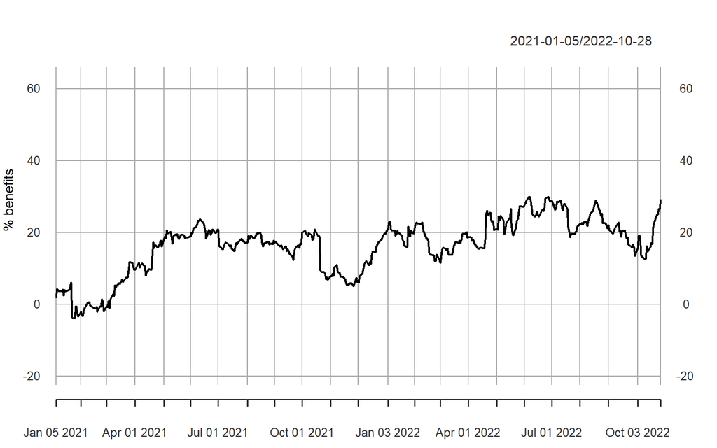

```r
# Obtain adjusted closed
IBad = IBM$IBM.Adjusted
TSad = TSLA$TSLA.Adjusted
# Compute cumulative sum (cumsum) of daily returns (Delt)
ib = cumsum((Delt(IBad)*100)[-1,]); ts = cumsum((Delt(TSad)*100)[-1,])
# Range of values for the plot
lim = c(min(ib,ts),max(ib,ts))
# The plot
plot(ib, main="", ylim=lim, xlab="dates", ylab="% benefits")
```

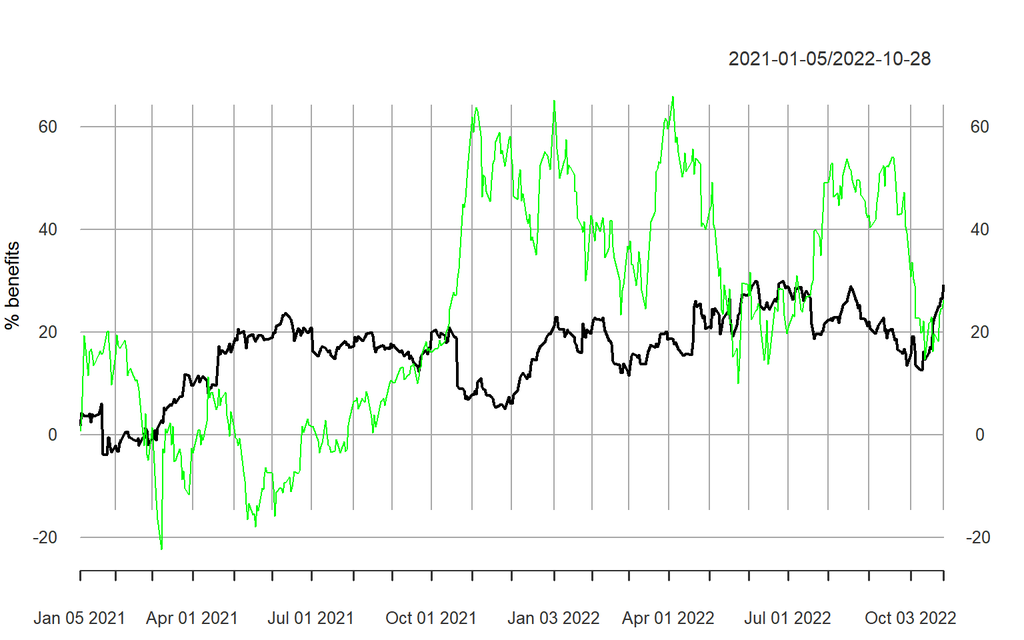

```r
lines(ts, col="green")
legend(x="topleft",cex=0.4,c("IBM","TSLA"),lty=1,col=c("black","green"))
```

## Question b

To compute rate of returns from a given time series and cumulative sum of the stocks in question `a.` Please explain the results obtained.

```r
# Description
str(IBM)
str(TSLA)
```

[output not shown]

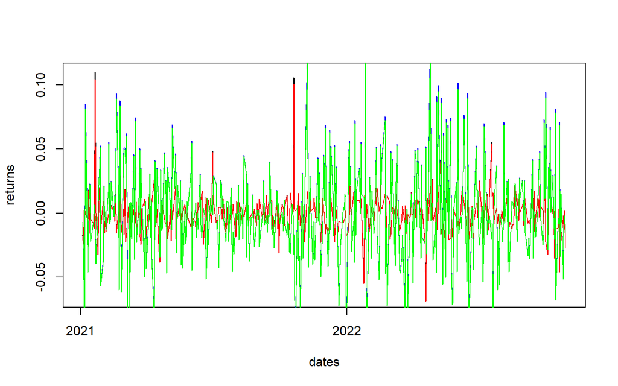

```r
# Load data
t1 = ISOdate(2021, 01, 01, hour=0)
t2 = ISOdate(2022, 10, 31, hour=0)
stock = "IBM"
url = paste("https://query1.finance.yahoo.com/v7/finance/download/",
             stock, "?period1=", as.integer(t1),
             "&period2=", as.integer(t2),
             "&interval=1d&events=history",
             sep="")
IBM = read.csv(url)
stock = "TSLA"
url = paste("https://query1.finance.yahoo.com/v7/finance/download/",
             stock, "?period1=", as.integer(t1),
             "&period2=", as.integer(t2),
             "&interval=1d&events=history",
             sep="")
TSLA = read.csv(url)

# Extract data
IBAC = IBM$Adj.Close; TSAC = TSLA$Adj.Close
date = IBM$Date
date = as.Date(date)
# New dataframe
dax = data.frame(date, IBAC, TSAC)
# Compute rate of return
ibmR = 1:460
tslR = 1:460
for (i in 1:460){ibmR[i]<-(IBAC[i]/IBAC[i+1])-1}
for (i in 1:460){tslR[i]<-(TSAC[i]/TSAC[i+1])-1}
daxR = data.frame(dax$date, ibmR, tslR)
daxRlog = log(daxR[2:3]+1)

# Plot
plot(dax$date, daxR$ibmR, type="l", main="",
     xlab="dates", ylab="returns", col="black")
lines(dax$date, daxRlog$ibmR, type="l", col="red")
lines(dax$date, daxR$tslR, type="l", col="blue")
lines(dax$date, daxRlog$tslR, type="l", col="green")
```

## Question c

The descriptive statistics of financial returns of the stocks in question `a.` Please explain the results obtained.

```r
# Basic statistics
basicStats(daxRlog)
```

```
##                   ibmR       tslR
## nobs        460.000000 460.000000
## NAs           1.000000   1.000000
## Minimum      -0.068595  -0.179327
## Maximum       0.104306   0.129928
## 1. Quartile  -0.007914  -0.020345
## 3. Quartile   0.006778   0.021714
## Mean         -0.000527   0.000136
## Median       -0.000774  -0.001769
## Sum          -0.241759   0.062493
## SE Mean       0.000699   0.001759
## LCL Mean     -0.001900  -0.003321
## UCL Mean      0.000847   0.003593
## Variance      0.000224   0.001420
## Stdev         0.014973   0.037687
## Skewness      1.172841   0.002592
## Kurtosis     10.395884   1.722666
```

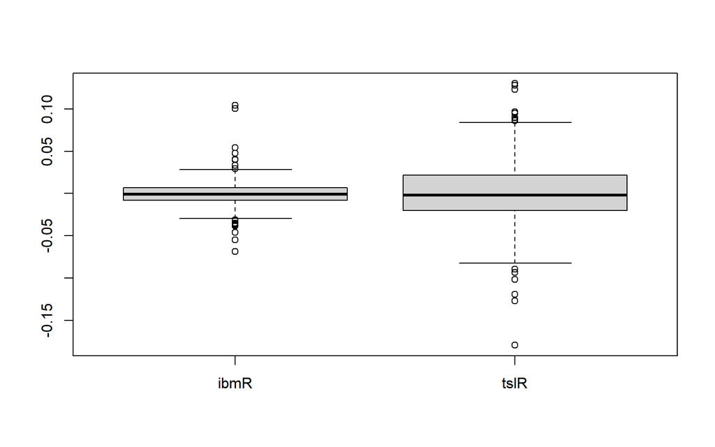

```r
# Boxplot - to visualize
boxplot(daxRlog)
```

```r
# Covariance matrix
cov(daxRlog, use="complete.obs")
```

```
##              ibmR         tslR
## ibmR 2.241846e-04 5.733507e-05
## tslR 5.733507e-05 1.420275e-03
```

## Question d

From question `b.` and `c.`, use quantile for `(0,1,0.25,0.5,0.75)`. Please explain the results obtained.

```r
# Remove NA values
ibm = na.omit(daxR$ibmR)
tsl = na.omit(daxR$tslR)
# Quantile
quantile(ibm, probs=c(0,1,0.25,0.5,0.75))
```

```
##            0%          100%           25%           50%           75%
## -0.0662956967  0.1099401220 -0.0078830145 -0.0007738964  0.0068007036
```

```r
quantile(tsl, probs=c(0,1,0.25,0.5,0.75))
```

```
##           0%         100%          25%          50%          75%
## -0.164167578  0.138746228 -0.020138979 -0.001767186  0.021951237
```

## Question e

From question `b.` and `c.`, please plot an estimate of its density from the sample (with a solid line). Please explain the results obtained.

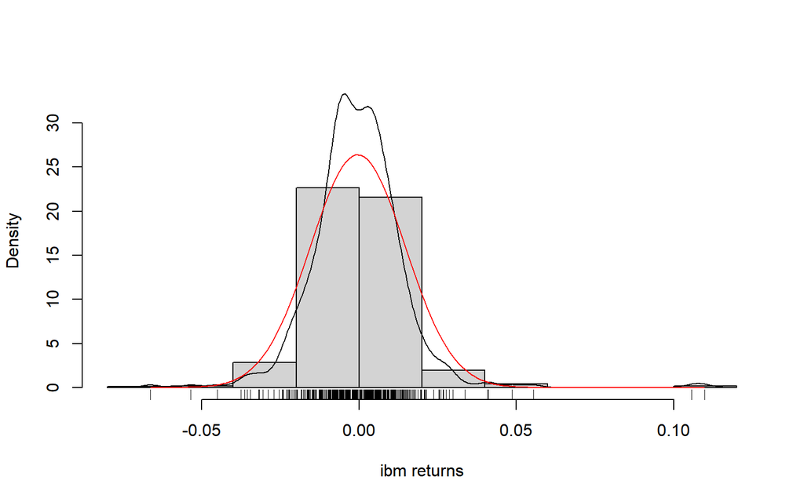

```r
# IBM
ibm = na.omit(daxR$ibmR)
DS = density(ibm)
yl = c(min(DS$y), max(DS$y)) #set y limits
hist(ibm, probability=T, xlab="ibm returns", main=NULL, ylim=yl)
rug(ibm)
lines(DS)
a = seq(min(ibm), max(ibm),0.001)
lines(a,dnorm(a,mean(ibm), sd(ibm)),col="red")
```

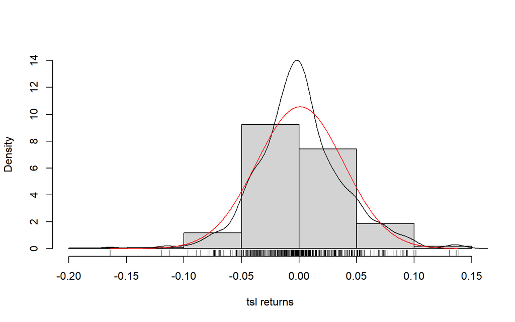

```r
# TSLA
tsl = na.omit(daxR$tslR)
DS = density(tsl)
yl = c(min(DS$y), max(DS$y)) #set y limits
hist(tsl, probability=T, xlab="tsl returns", main=NULL, ylim=yl)
rug(tsl)
lines(DS)
a = seq(min(tsl), max(tsl),0.001)
lines(a,dnorm(a,mean(tsl), sd(tsl)),col="red")
```

## Extra

```r
# exponential curve
getSymbols("IBM", src="yahoo")
```

```
## [1] "IBM"
```

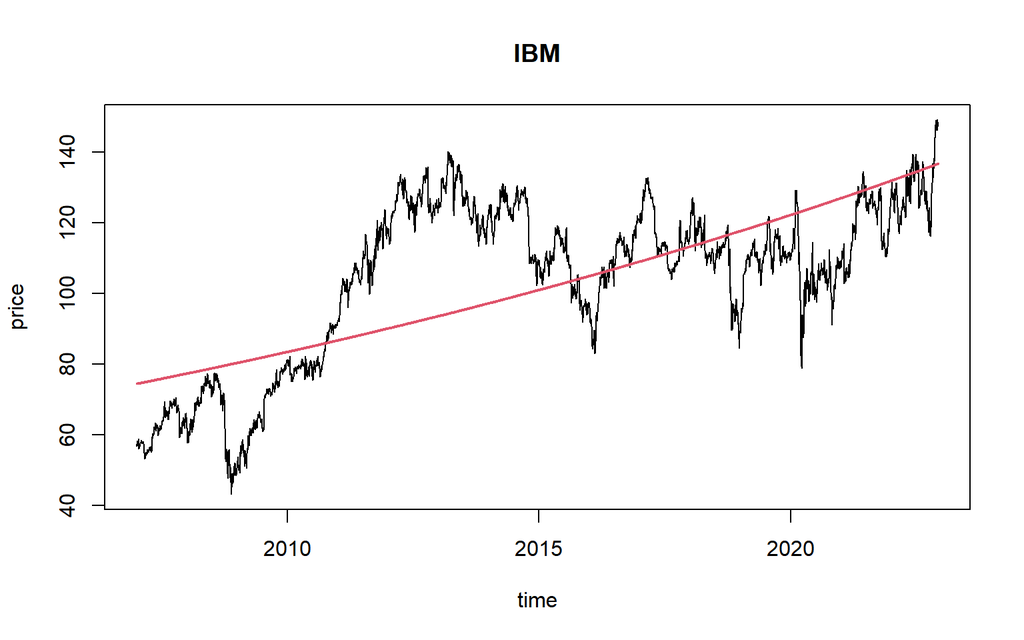

```r
serie = IBM$IBM.Adjusted
price = as.numeric(serie) # extract numeric values of price
time = index(serie) # extract the indices
x = 1:length(price)

# Model
model = lm(log(price)~x)
expo = exp(model$coef[1]+model$coef[2]*x)

# Plot
plot(x=time, y=price, main="IBM", type="l")
lines(time, expo, col=2, lwd=2)
```

```r
getSymbols("IBM", src="yahoo")
```

```
## [1] "IBM"
```

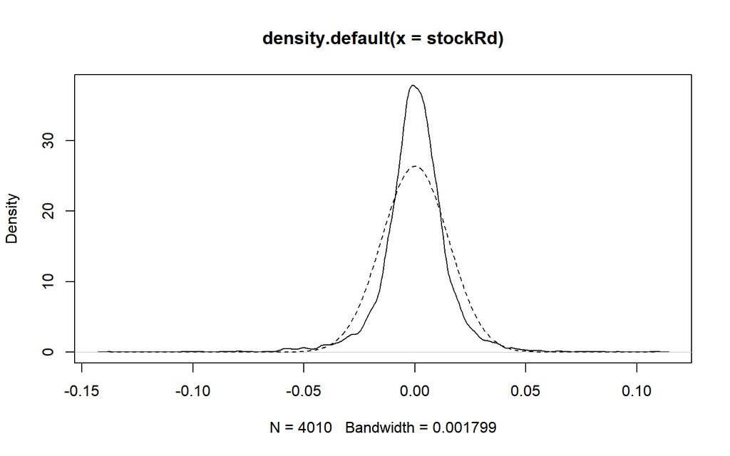

```r
stock = IBM

stockRd = periodReturn(stock, period="daily", type="log")
dsd = density(stockRd)
yl = c(min(dsd$y), max(dsd$y))

# Plot
plot(dsd, main=NULL, ylim=yl)
a = seq(min(stockRd), max(stockRd), 0.001)
points(a, dnorm(a, mean(stockRd), sd(stockRd)), type="l", lty=2)
```

```r
getSymbols("IBM", src="yahoo")
```

```
## [1] "IBM"
```

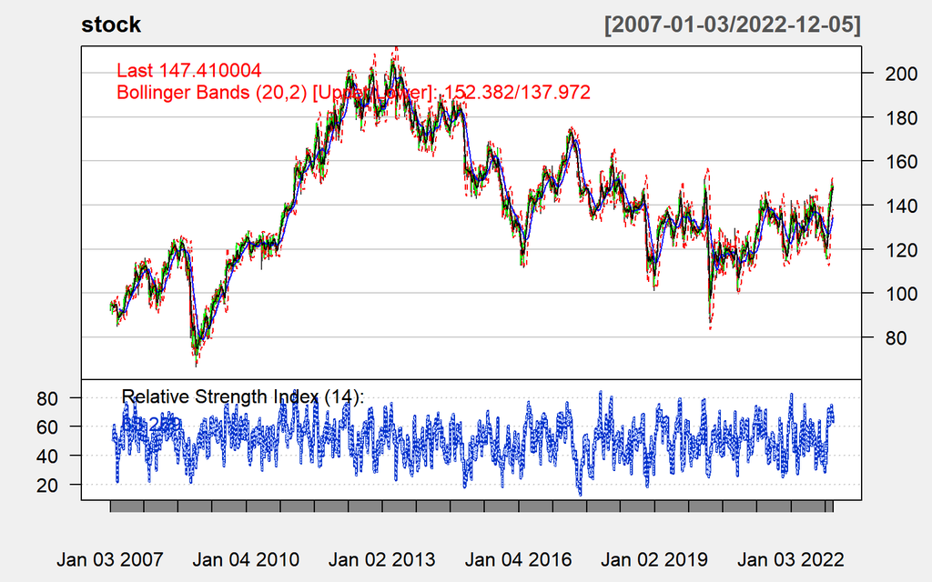

```r
chartSeries(stock, subset=NULL,
            theme=chartTheme("white",up.col="green",dn.col="red"),
            TA=c(addBBands(n=20,sd=2,),addSMA(n=50,col="blue"),
                 addSMA(n=10,col="black"),addRSI(n=14)))
```

```r
library(jsonlite)
library(httr)
# getFinancials function is no longer worked
# Therefore, these are new functions that work as getFinancials
transpose_df <- function(df_list){
  df_list$maxAge <- NULL
  myColnames <- df_list$endDate$fmt
  df_list$endDate <- NULL

  mydf <- data.frame(row.names = colnames(df_list))

  for (i in 1:length(df_list)) {
    for (j in 1:4) {
      tryCatch(
        {
          mydf[i,j] <- df_list[j,i]$raw
        },
        error = function(cond){
          mydf[i,j] <- NA
        }
      )

    }
  }
  colnames(mydf) <- myColnames
  return(mydf)
}

getFinReports <- function(stock){
  for (i in 1:length(stock)) {
    tryCatch(
      {
        url <- paste0('https://query1.finance.yahoo.com/v10/finance/quoteSummary/',stock[i],'?formatted=true&lang=en-US&region=US&modules=incomeStatementHistory%2CcashflowStatementHistory%2CbalanceSheetHistory&corsDomain=finance.yahoo.com')
        a <- GET(url)
        a <- content(a, as="text")

        df <- fromJSON(a, simplifyDataFrame = TRUE)

        df_is <- df$quoteSummary$result$incomeStatementHistory$incomeStatementHistory[[1]]
        df_is <- transpose_df(df_is)

        df_bs <- df$quoteSummary$result$balanceSheetHistory$balanceSheetStatements[[1]]
        df_bs <- transpose_df(df_bs)

        df_cs <- df$quoteSummary$result$cashflowStatementHistory$cashflowStatements[[1]]
        df_cs <- transpose_df(df_cs)
        assign(paste0(stock[i],'.f'),value = list(IS = df_is,BS = df_bs,CF = df_cs),envir = parent.frame())
      },
      error = function(cond){
        message(stock[i], "Give error ",cond)
      }
    )
  }
}
```

```r
getFinReports('AAPL')
AAPL.f$BS
```

```
##                           2022-09-24  2021-09-25   2020-09-26   2019-09-28
## cash                     23646000000 3.49400e+10  38016000000  48844000000
## shortTermInvestments     24658000000 2.76990e+10  52927000000  51713000000
## netReceivables           60932000000 5.15060e+10  37445000000  45804000000
## inventory                 4946000000 6.58000e+09   4061000000   4106000000
## otherCurrentAssets       21223000000 1.41110e+10  11264000000  12352000000
## totalCurrentAssets      135405000000 1.34836e+11 143713000000 162819000000
## longTermInvestments     120805000000 1.27877e+11 100887000000 105341000000
## propertyPlantEquipment   52534000000 4.95270e+10  45336000000  37378000000
## otherAssets              44011000000 3.87620e+10  33952000000  32978000000
## totalAssets             352755000000 3.51002e+11 323888000000 338516000000
## accountsPayable          64115000000 5.47630e+10  42296000000  46236000000
## shortLongTermDebt        11128000000 9.61300e+09   8773000000  10260000000
## otherCurrentLiab         67094000000 5.35770e+10  47867000000  43242000000
## longTermDebt             98959000000 1.09106e+11  98667000000  91807000000
## otherLiab                38394000000 4.30500e+10  46108000000  50503000000
## totalCurrentLiabilities 153982000000 1.25481e+11 105392000000 105718000000
## totalLiab               302083000000 2.87912e+11 258549000000 248028000000
## commonStock              64849000000 5.73650e+10  50779000000  45174000000
## retainedEarnings         -3068000000 5.56200e+09  14966000000  45898000000
## treasuryStock           -11109000000 1.63000e+08   -406000000   -584000000
## otherStockholderEquity  -11109000000 1.63000e+08   -406000000   -584000000
## totalStockholderEquity   50672000000 6.30900e+10  65339000000  90488000000
## netTangibleAssets        50672000000 6.30900e+10  65339000000  90488000000
```

```r
colnames(AAPL.f$BS)
```

```
## [1] "2022-09-24" "2021-09-25" "2020-09-26" "2019-09-28"
```

```r
rownames(AAPL.f$BS)
```

```
##  [1] "cash"                    "shortTermInvestments"
##  [3] "netReceivables"          "inventory"
##  [5] "otherCurrentAssets"      "totalCurrentAssets"
##  [7] "longTermInvestments"     "propertyPlantEquipment"
##  [9] "otherAssets"             "totalAssets"
## [11] "accountsPayable"         "shortLongTermDebt"
## [13] "otherCurrentLiab"        "longTermDebt"
## [15] "otherLiab"               "totalCurrentLiabilities"
## [17] "totalLiab"               "commonStock"
## [19] "retainedEarnings"        "treasuryStock"
## [21] "otherStockholderEquity"  "totalStockholderEquity"
## [23] "netTangibleAssets"
```

```r
CA = AAPL.f$BS["totalCurrentAssets", "2022-09-24"]
CL = AAPL.f$BS["totalCurrentLiabilities", "2022-09-24"]
CA/CL # Current Ratio
```

```
## [1] 0.879356
```

```r
library(fTrading)
# The moving average of on a period of 10 days
# for the time series object IBM
getSymbols("IBM", src="yahoo")
SMA(IBM, n = 10)
```

[output not shown]